# Independent_Project

```r
# Then, apply the factor function to create a factor from the vector
factor_data <- factor(advertising$Clicked.on.Ad)

# Then see our newly created factor
factor_data
```

```
## factor(0)
## Levels:
```

```r
# Check whether this is a factor
is.factor(factor_data)
```

```
## [1] TRUE
```

```r
# Fetching the county column
# ---
#
Country <- advertising$Country

# Applying the table() function will compute the frequency distribution of the School variable
# ---
#
country_frequency <- table(Country)

# Printing school_frequency below
# ---
#
country_frequency
```

[output not shown]

[output cut: 420 more lines]

[output not shown]

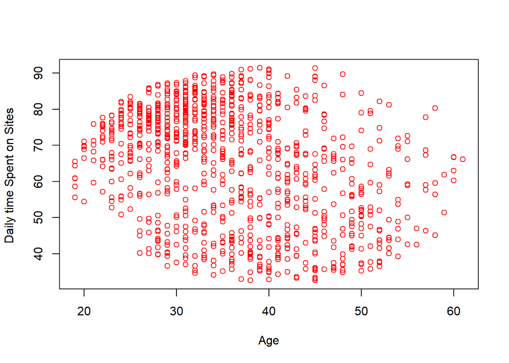

```r
plot( advertising$`Age`,advertising$`Daily Time Spent on Site`, xlab = "Age", ylab = "Daily time Spent on Sites ", col = "red")
```

People between the age 40 and below spend much time on the sites While people aged 50 and above spend less time on sites

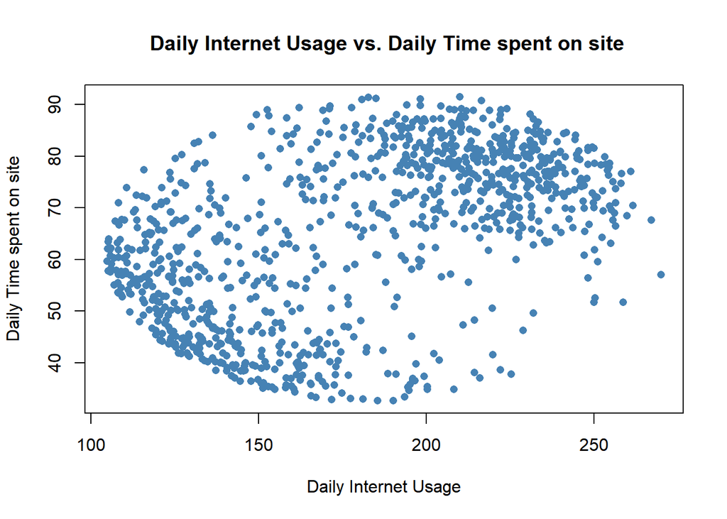

```r
#create scatterplot of Daily Internet Usage vs. Time spent on site
plot(advertising$`Daily Internet Usage`, advertising$`Daily Time Spent on Site`, pch=16, col='steelblue',
     main=' Daily Internet Usage vs. Daily Time spent on site',
     xlab='Daily Internet Usage', ylab='Daily Time spent on site')
```

People with high daily internet usage spend higher time on sites

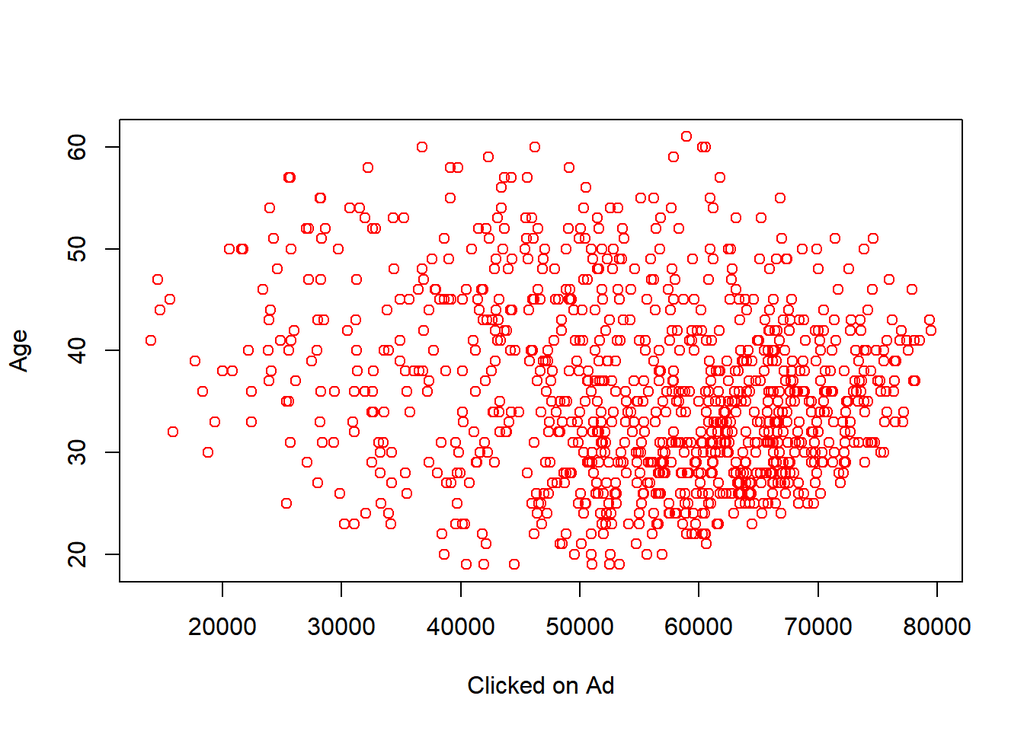

```r
plot(advertising$`Area Income` ,advertising$`Age`, xlab= "Clicked on Ad", ylab = "Age", col = "red")
```

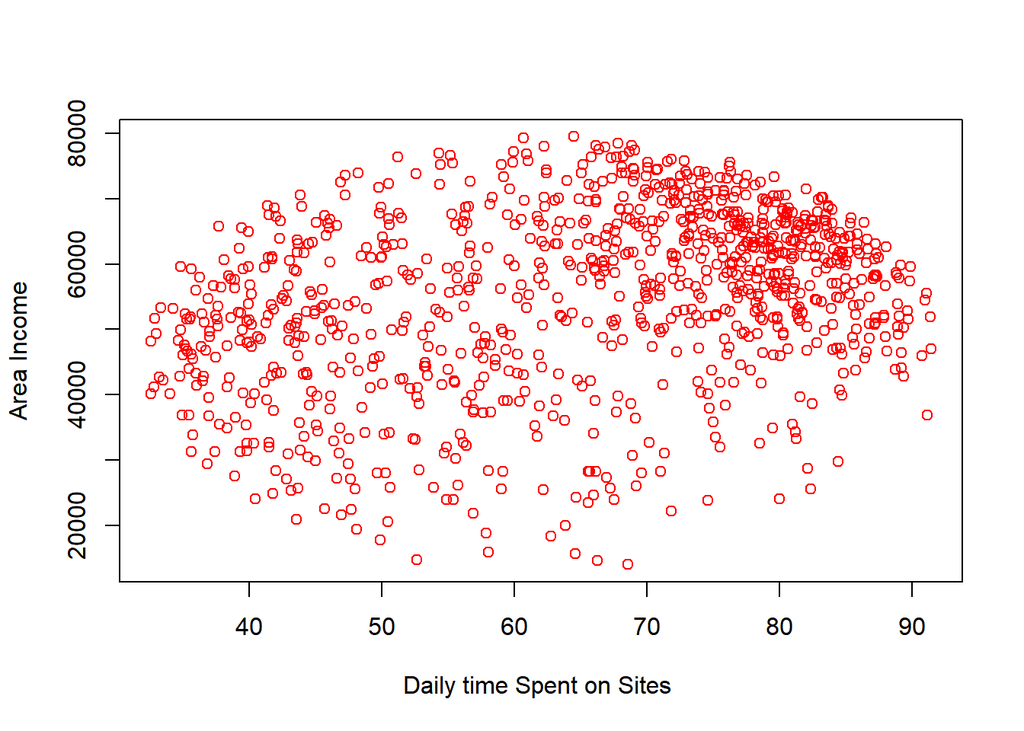

```r
plot( advertising$`Daily Time Spent on Site`,advertising$`Area Income`, xlab = "Daily time Spent on Sites ", ylab = "Area Income", col = "red")
```

People with High area income spend more time on sites

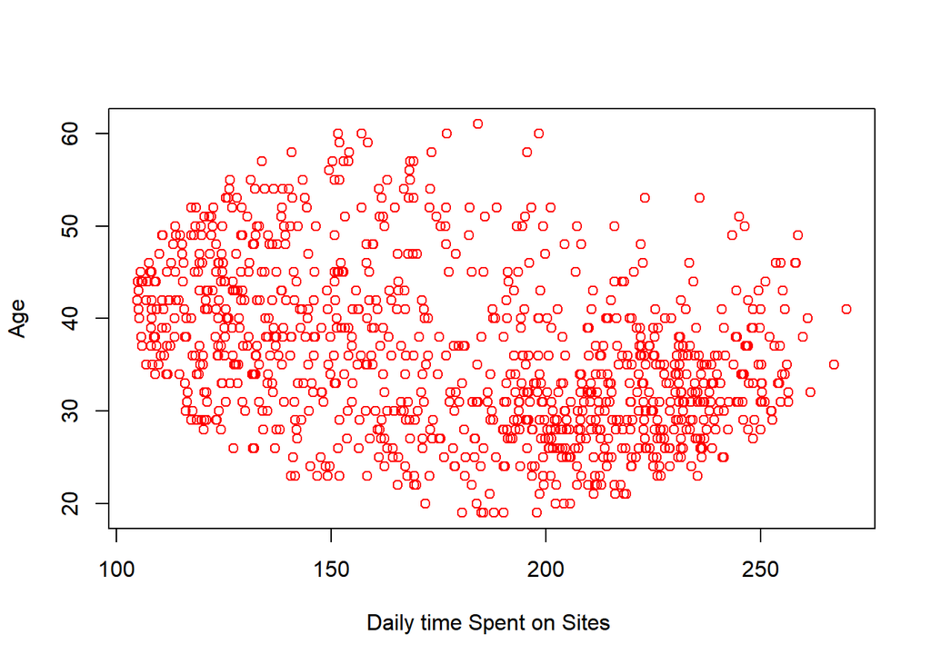

```r
plot( advertising$`Daily Internet Usage`,advertising$Age, xlab = "Daily time Spent on Sites ", ylab = "Age", col = "red")
```

People aged 30 and below have high internet usage

```r
#calculate correlation between Ads Clicked on Ads and Daily internet Usage
cor(advertising$`Clicked on Ad`, advertising$`Daily Internet Usage`)
```

```
## [1] -0.7865392
```

There is a negative correlation between the Daily internt usage and those individuals that click on Ads

```r
#calculate correlation between Ads clicked and Daily Time spent on site
cor(advertising$`Clicked on Ad`, advertising$`Daily Time Spent on Site`)
```

```
## [1] -0.7481166
```

There is a negative correlation between the Daily time spent on sites and those individuals that click on Ads

2 There are more females to males in the sites,where 1 is Male,0 is Female

3 The youngest Age is 19 and the Oldest age in the website client is 61

4 Minimum Age is 19 Maximum age is 61

5 Highest Age frequency is from the people in age 31,followed by,37,28,29

6 Most people earn between 40,000 and 75,000 Very few people earn over 75,000 and below 35,000

8 People between the age 40 and below spend much time on the sites While people aged 50 and above spend less time on sites

9 People with high daily internet usage spend higher time on sites

11 People with High area income spend more time on sites

12 People aged 30 and below have high internet usage

2 Focus on sending ads to individuals with high income as they spend more time on the sites

4 People aged 40 are a good client market for the ads because they alot of time on the sites